# Lab 6: Lasso and clustering

Willem van den Boom

Consider again the diabetes data used in Lab 2 and Application Exercise 6. It is the data used in Efron et al. (2004, http://www.jstor.org/stable/3448465). and provided as part of the `lars` R package. Let us load these data.

```r
library(lars)
data(diabetes)
```

The object `diabetes` is a data frame with 3 variables. We will be working with `y` as outcome and `x` as the design matrix: `x` contains candidate predictors, including age, sex, body mass index (bmi), and mean arterial blood pressure (map) for each of n = 442 diabetes patients, as well as the response of interest, a quantitative measure of disease (diabetes) progression one year after baseline.

Previously, we used the `glmnet` package to fit the lasso. The `lars` package provides an alternative, with a focus on the ``trajectory’’ of the coefficients as the regularization constant changes. For instance, the following code estimates lasso regression at all values of the regularization parameter where a predictor is added or removed from the model.

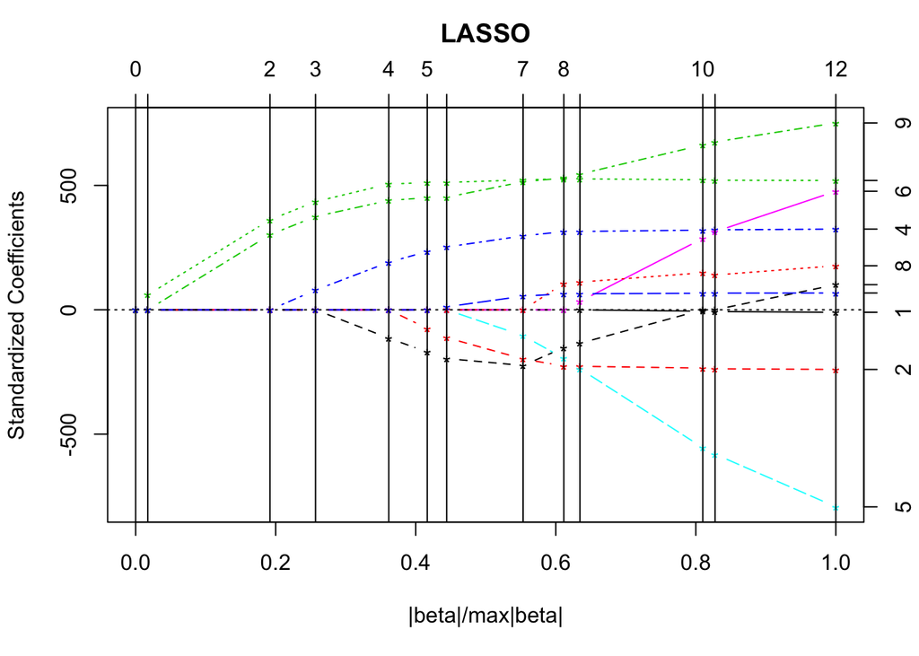

```r
object <- lars(x = diabetes$x, y = diabetes$y)
plot(object)
```

1. Give a description of what the last plot means in relation to the lasso coefficient estimates and the lasso regularization parameter: What do the lines represent? How does the lasso regularization parameter vary with the x-axis?

#### 15 pts

2. The black dashed line in the last plot is not monotone: It first decreases and then starts to increase. What does this mean or what could be a reason for this?

#### 10 pts

The coefficient estimates at the points in the last plot can be obtained by running `coef(object)`.

3. Which 2 predictors are selected into the model first by lasso?

#### 10 pts

Let us now investigate these data using k-means. Use the R function `kmeans` from the R package `cluster` with `nstart = 25` as in the textbook.

If you get

```r
Error in if (mm < k) stop("more cluster centers than distinct data points.") :
  argument is of length zero
```

then that might be caused by the fact that `diabetes$x2` is of the R class `AsIs`. Running `class(diabetes$x2) <- NULL` removes this class attribute, and should resolve the error.

4. What does the argument `nstart` of the function `kmeans` represent? Why is it better to use `nstart = 25` than the function’s default of `nstart = 1`?

#### 10 pts

5. Consider the data with as only variables the 2 that the lasso selected in Exercise 3. Pick a number $k$ of clusters for your k-means analysis. Base your answer on the within sum of squares (WSS).

#### 25 pts

6. Visualize the results of the k-means analysis using the $k$ chosen in Exercise 5. A suitable visualization is for instance Figure 4-6 from the textbook.

#### 20 pts

If you follow the code on page 216, please be aware that the argument `show_guide` of the function `ggplot` has been deprecated and should be replaced by `show.legend`.

7. Provide an interpretation of what each of the $k$ clusters obtained in Exercise 6 mean.

#### 10 pts